# Danish Kings

Manuel Ø. Mørch

2026-03-13

## Load the kings

1. Look at the dataset that are you loading and check what its columns are separated by?

*In monarchs.csv the seperator is “,”*

2. Create a `kings` object in R with the different functions below and inspect the different outputs.
- `read.csv()`
- `read_csv()`
- `read.csv2()`
- `read_csv2()`

```r
# FILL IN THE CODE BELOW and review the outputs
kings1 <- read.csv("data/monarchs.csv", na="NULL")
kings1
```

```
##              name birth_year death_year reign_start reign_end
## 1    Frederik_10.       1968         NA        2024        NA
## 2   Margrethe_ 2.       1940         NA        1972      2024
## 3     Frederik_9.       1899       1972        1947      1972
## 4   Christian_10.       1870       1947        1912      1947
## 5     Frederik_8.       1843       1912        1906      1912
## 6    Christian_9.       1818       1906        1863      1906
## 7     Frederik_7.       1808       1863        1848      1863
## 8    Christian_8.       1786       1848        1839      1848
## 9     Frederik_6.       1768       1839        1808      1839
## 10   Christian_7.       1749       1808        1766      1808
## 11    Frederik_5.       1723       1766        1746      1766
## 12   Christian_6.       1699       1746        1730      1746
## 13    Frederik_4.       1671       1730        1699      1730
## 14   Christian_5.       1646       1699        1670      1699
```

[output cut: 41 more lines]

```r
# kings 1 Works fine but it is not a tibble, it is a data frame.

kings2 <- read_csv("data/monarchs.csv", na="NULL")
kings2
```

```
## # A tibble: 55 × 5
##    name          birth_year death_year reign_start reign_end
##    <chr>         <chr>      <chr>      <chr>       <chr>
##  1 Frederik_10.  1968       NA         2024        NA
##  2 Margrethe_ 2. 1940       NA         1972        2024
##  3 Frederik_9.   1899       1972       1947        1972
##  4 Christian_10. 1870       1947       1912        1947
##  5 Frederik_8.   1843       1912       1906        1912
##  6 Christian_9.  1818       1906       1863        1906
##  7 Frederik_7.   1808       1863       1848        1863
##  8 Christian_8.  1786       1848       1839        1848
##  9 Frederik_6.   1768       1839       1808        1839
## 10 Christian_7.  1749       1808       1766        1808
## # ℹ 45 more rows
```

```r
# kings2 Works perfectly and it is a tibble.

kings3 <- read.csv2("data/monarchs.csv", na="NULL")
kings3
```

```
##    name.birth_year.death_year.reign_start.reign_end
## 1                      Frederik_10.,1968,NA,2024,NA
## 2                   Margrethe_ 2.,1940,NA,1972,2024
## 3                   Frederik_9.,1899,1972,1947,1972
## 4                 Christian_10.,1870,1947,1912,1947
## 5                   Frederik_8.,1843,1912,1906,1912
## 6                  Christian_9.,1818,1906,1863,1906
## 7                   Frederik_7.,1808,1863,1848,1863
## 8                  Christian_8.,1786,1848,1839,1848
## 9                   Frederik_6.,1768,1839,1808,1839
## 10                 Christian_7.,1749,1808,1766,1808
## 11                  Frederik_5.,1723,1766,1746,1766
## 12                 Christian_6.,1699,1746,1730,1746
## 13                  Frederik_4.,1671,1730,1699,1730
## 14                 Christian_5.,1646,1699,1670,1699
```

[output cut: 41 more lines]

```r
# kings3 does not work, it reads the whole dataset as one column

kings4 <- read_csv2( "data/monarchs.csv", na="NULL")
```

```
## ℹ Using "','" as decimal and "'.'" as grouping mark. Use `read_delim()` for more control.
```

```r
kings4
```

```
## # A tibble: 55 × 1
##    `name,birth_year,death_year,reign_start,reign_end`
##    <chr>
##  1 Frederik_10.,1968,NA,2024,NA
##  2 Margrethe_ 2.,1940,NA,1972,2024
##  3 Frederik_9.,1899,1972,1947,1972
##  4 Christian_10.,1870,1947,1912,1947
##  5 Frederik_8.,1843,1912,1906,1912
##  6 Christian_9.,1818,1906,1863,1906
##  7 Frederik_7.,1808,1863,1848,1863
##  8 Christian_8.,1786,1848,1839,1848
##  9 Frederik_6.,1768,1839,1808,1839
## 10 Christian_7.,1749,1808,1766,1808
## # ℹ 45 more rows
```

```r
# kings4 does not work, it reads the whole dataset as one column
```

Answer: *kings2 is what works for my .csv file*

1. Which of these functions is a `tidyverse` function? Read data with it below into a `kings` object

Answer: *read_csv is a tidyverse function.*

2. What is the result of running `class()` on the `kings` object created with a tidyverse function.

Answer: *“spec_tbl_df” “tbl_df” “tbl” “data.frame” which tells us it is a tibble*

3. How many columns does the object have when created with these different functions?

Answer: *read.csv created 5 columns, read_csv created 5 columns, read.csv2 created 1 column and read_csv2 created 1 column.*

4. Show the dataset so that we can see how R interprets each column

*Where i wrote head(kings) you can see that it interprets all columns as characters, so i have to remember to coerce the start and end of reign columns to numbers before i can do calculations on them.*

```r
# COMPLETE THE BLANKS BELOW WITH YOUR CODE, then turn the 'eval' flag in this chunk to TRUE.
library(tidyverse)
kings <- read_csv("data/monarchs.csv", na="NULL")
class(kings)
```

```
## [1] "spec_tbl_df" "tbl_df"      "tbl"         "data.frame"
```

```r
head(kings)
```

```
## # A tibble: 6 × 5
##   name          birth_year death_year reign_start reign_end
##   <chr>         <chr>      <chr>      <chr>       <chr>
## 1 Frederik_10.  1968       NA         2024        NA
## 2 Margrethe_ 2. 1940       NA         1972        2024
## 3 Frederik_9.   1899       1972       1947        1972
## 4 Christian_10. 1870       1947       1912        1947
## 5 Frederik_8.   1843       1912       1906        1912
## 6 Christian_9.  1818       1906       1863        1906
```

```r
glimpse(kings)
```

```
## Rows: 55
## Columns: 5
## $ name        <chr> "Frederik_10.", "Margrethe_ 2.", "Frederik_9.", "Christian…
## $ birth_year  <chr> "1968", "1940", "1899", "1870", "1843", "1818", "1808", "1…
## $ death_year  <chr> "NA", "NA", "1972", "1947", "1912", "1906", "1863", "1848"…
## $ reign_start <chr> "2024", "1972", "1947", "1912", "1906", "1863", "1848", "1…
## $ reign_end   <chr> "NA", "2024", "1972", "1947", "1912", "1906", "1863", "184…
```

## Calculate the duration of reign for all the kings in your table

Create a new column called `duration` in the kings dataset, utilizing the `mutate()` function from tidyverse.

*(I just had to convert it so it understood my reign_start and reign_end as numbers, not characters, and then I could just subtract them to get the duration of reign in years.)*

```r
# Calculating duration

#first i have to make sure it reads the data correctly, so everything except for the names should be read as numbers, not characters.
kings <- kings %>%
  mutate(across(-name, as.numeric))
# Then i can calculate the duration of reign by subtracting the start from the end of reign.

kings <- kings %>%
  mutate(duration = reign_end - reign_start)
kings
```

```
## # A tibble: 55 × 6
##    name          birth_year death_year reign_start reign_end duration
##    <chr>              <dbl>      <dbl>       <dbl>     <dbl>    <dbl>
##  1 Frederik_10.        1968         NA        2024        NA       NA
##  2 Margrethe_ 2.       1940         NA        1972      2024       52
##  3 Frederik_9.         1899       1972        1947      1972       25
##  4 Christian_10.       1870       1947        1912      1947       35
##  5 Frederik_8.         1843       1912        1906      1912        6
##  6 Christian_9.        1818       1906        1863      1906       43
##  7 Frederik_7.         1808       1863        1848      1863       15
##  8 Christian_8.        1786       1848        1839      1848        9
##  9 Frederik_6.         1768       1839        1808      1839       31
## 10 Christian_7.        1749       1808        1766      1808       42
## # ℹ 45 more rows
```

## Calculate the average duration of reign for all rulers

So you need to subset your `kings` dataset to the `duration` column. If you subset it as a vector you can calculate average on it with `mean()` base-R function. If you subset it as a tibble, you can calculate average on it with `summarize()` tidyverse function. Try both ways!

- You first need to know how to select the relevant `duration` column. What are your options? Answer: *You can select the duration column with either `kings$duration` or with `select(duration)`*
- Is your selected `duration` column a tibble or a vector? The `mean()` function can only be run on a vector. The `summarize()` function works on a tibble. Answer: *If i select the duration column with `kings$duration` it is a vector, if i select it with `select(duration)` it is a tibble.*
- Are you getting an error that there are characters in your column? Coerce your data to numbers with `as.numeric()`. *I already did that in the previous step*
- Remember to handle NAs: `mean(X, na.rm=TRUE)` *done*

```r
# Calculating average duration

# Vector approach
avg_years_ruled_vector <- mean(kings$duration, na.rm = TRUE)
avg_years_ruled_vector
```

```
## [1] 20.09615
```

```r
# Tibble approach
avg_years_ruled_tibble <- kings %>%
  summarize(avg_years_ruled = mean(duration, na.rm = TRUE))
# Here i also have to use pull() so it will display just the number instead of a tibble
pull(avg_years_ruled_tibble)
```

```
## [1] 20.09615
```

*The average duration of reign is 20.0961538 years.*

## How many and which kings enjoyed a longer-than-average duration of reign?

Display the result and also count the resulting rows with `count()`

```r
# longer-than-average duration of reign

# Because i have to use pull() to just get the number with the tibble version, it is best to just use the vector version here.
# I will also arrange them in descending order. Just to make it nice
kings %>%
  filter(duration > avg_years_ruled_vector) %>%
  select(name, duration) %>%
  arrange(desc(duration))
```

```
## # A tibble: 23 × 2
##    name          duration
##    <chr>            <dbl>
##  1 Christian_4.        60
##  2 Margrethe_ 2.       52
##  3 Christian_9.        43
##  4 Erik_7.             43
##  5 Christian_7.        42
##  6 Valdemar_2.         39
##  7 Valdemar_1.         36
##  8 Christian_10.       35
##  9 Valdemar_4.         35
## 10 Christian_1.        33
## # ℹ 13 more rows
```

```r
# and to count how many had longer-than-average reign:
kings %>%
  filter(duration > avg_years_ruled_vector) %>%
  count()
```

```
## # A tibble: 1 × 1
##       n
##   <int>
## 1    23
```

## How many days did the three longest-ruling monarchs rule?

- Sort kings by reign `duration` in the descending order. Select the three longest-ruling monarchs with the `slice()` function
- Use `mutate()` to create `Days` column where you calculate the total number of days they ruled
- BONUS: consider the transition year (with 366 days) in your calculation!

```r
# YOUR CODE
# Monarchs sorted by reign duration in descending order. Then selecting the tree longest-ruling monarchs
kings %>%
  arrange(desc(duration)) %>%
  slice(1:3) %>%
# Calculating the total number of days they ruled while considering the transition year (with 366 days) in the calculation.
#Transition years/leap years are roughly every 4 years, so i just use 365.25 instead of 365.
  mutate(days = duration * 365.25) %>%
  select(name, duration, days)
```

```
## # A tibble: 3 × 3
##   name          duration   days
##   <chr>            <dbl>  <dbl>
## 1 Christian_4.        60 21915
## 2 Margrethe_ 2.       52 18993
## 3 Christian_9.        43 15706.
```

## Challenge: Plot the kings’ duration of reign through time

What is the long-term trend in the duration of reign among Danish monarchs? How does it relate to the historical violence trends ?

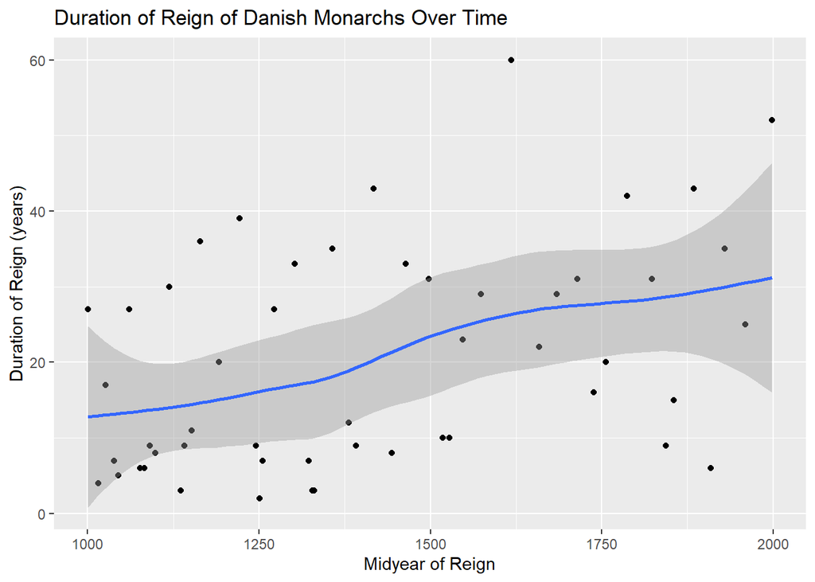

```r
# YOUR CODE

mutate(kings, midyear = reign_start + ((reign_end - reign_start)/2)) %>%
  ggplot(aes(x = midyear, y = duration)) +
  geom_point() +
  geom_smooth() +
  labs(title = "Duration of Reign of Danish Monarchs Over Time",
       x = "Midyear of Reign",
       y = "Duration of Reign (years)")
```